# SPOOKY Data Analysis

Mao Guan

January 30, 2018

# Introduction

“As I scurried across the candlelit chamber, manuscripts in hand, I thought I’d made it. Nothing would be able to hurt me anymore. Little did I know there was one last fright lurking around the corner.” This is a part of a horror story which terrifies and excites us. In the passage, we are going to analyze the data composed of horror stories written by Edgar Allan Poe, Mary Shelley, and HP Lovecraft. The data was prepared by chunking larger texts into sentences using CoreNLP’s MaxEnt sentence tokenizer. Specifically we would like to consider the similarities and the differences between the texts attributed to each author and study patterns that could be used to characterize the writing styles of the three authors.

# Libraries Preparation

```r
packages.used=c("corrgram","RSentiment","xgboost","ggridges")

# check packages that need to be installed.
packages.needed=setdiff(packages.used,
                        intersect(installed.packages()[,1],
                                  packages.used))
# install additional packages
if(length(packages.needed)>0){
  install.packages(packages.needed, dependencies = TRUE)
}

# general visualisation
library('ggplot2') # visualisation
library('scales') # visualisation
library('grid') # visualisation
library('gridExtra') # visualisation
library('RColorBrewer') # visualisation
library('corrplot') # visualisation

# general data manipulation
library('dplyr') # data manipulation
library('readr') # input/output
library('data.table') # data manipulation
library('tibble') # data wrangling
library('tidyr') # data wrangling
library('stringr') # string manipulation
library('forcats') # factor manipulation

# specific visualisation
#library('alluvial') # visualisation
library('ggrepel') # visualisation
#library('ggfortify')# visualisation
library('ggridges') # visualisation
#library('gganimate') # visualisation
#library('ggExtra') # visualisation
library('corrgram')

# specific data manipulation
library('lazyeval') # data wrangling
library('broom') # data wrangling
library('purrr') # string manipulation
library('reshape2') # data wrangling

# Text / NLP
library('tidytext') # text analysis
library('tm') # text analysis
library('SnowballC') # text analysis
library('topicmodels') # text analysis
library('wordcloud') # test visualisation
library('igraph') # visualisation
#library('ggraph') # visualisation
#library('babynames') # names
library("RSentiment")

# Models
library('Matrix')
library('xgboost')
#library('caret')

#library('treemapify') #visualisation
source("../libs/multiplot.R")
```

# Data Preparations

First, before we dive into the data. Let’s take a glimpse of the data offered.

```r
spookydata = read.csv('../data/spooky.csv', as.is = TRUE)
```

Then, let’s find whether the sentence length among the authors will vary much.

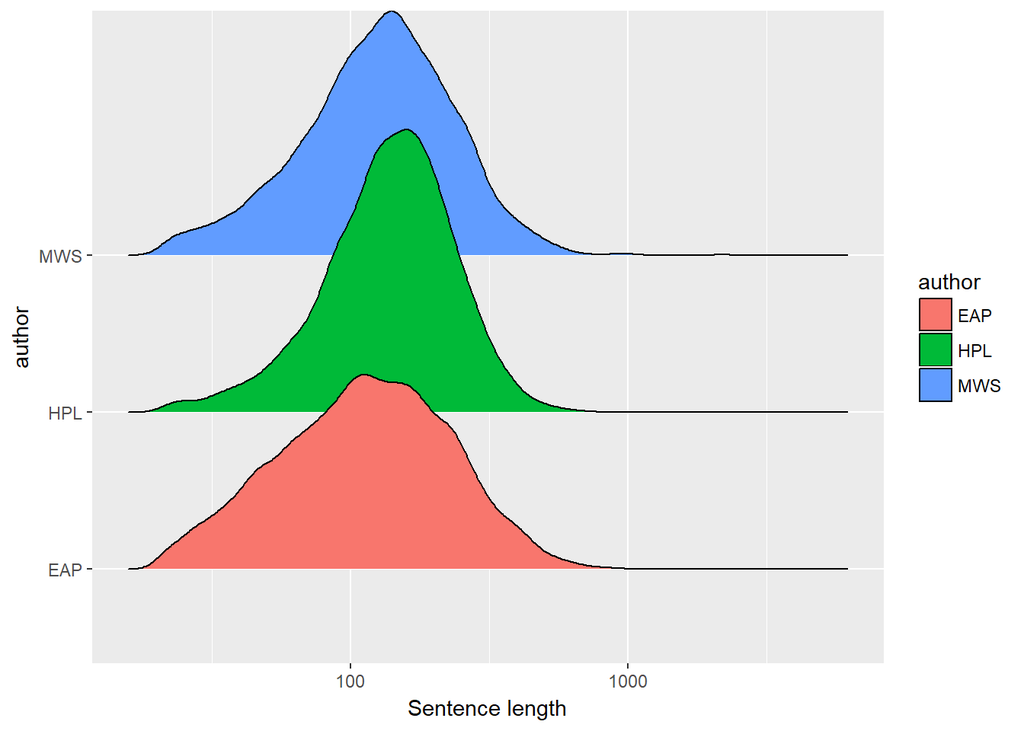

```r
p <- spookydata %>%
  mutate(sen_len = str_length(text)) %>%
  ggplot(aes(sen_len, author, fill = author)) +
  geom_density_ridges() +
  scale_x_log10() +
  theme(legend.position = "right") +
  labs(x = "Sentence length")

plot(p)
```

Second, let’s do some simple treatment to our data: remove the invalid information incluing tokens.

```r
spooky_wrd <- spookydata %>%
   unnest_tokens(word, text) %>%
   # remove stopwords
   anti_join(stop_words, by = "word") %>%
   count(author, word) %>%
   ungroup()
```

## Word Clouds

In this part, lets’ make a word cloud to see the most common words used by the three authors together and separately

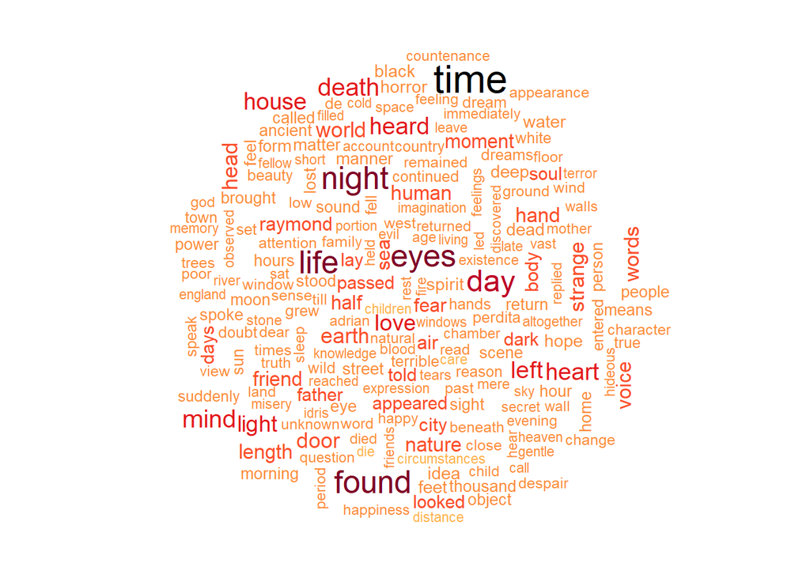

```r
spooky_wrd_all <- spooky_wrd %>%
  group_by(word) %>%
  summarise(n = sum(n)) %>%
  ungroup()

wordcloud(spooky_wrd_all$word, spooky_wrd_all$n,
          max.words = 200, scale = c(2.0,0.5),
          colors = RColorBrewer::brewer.pal(9, "YlOrRd")[4:10])
```

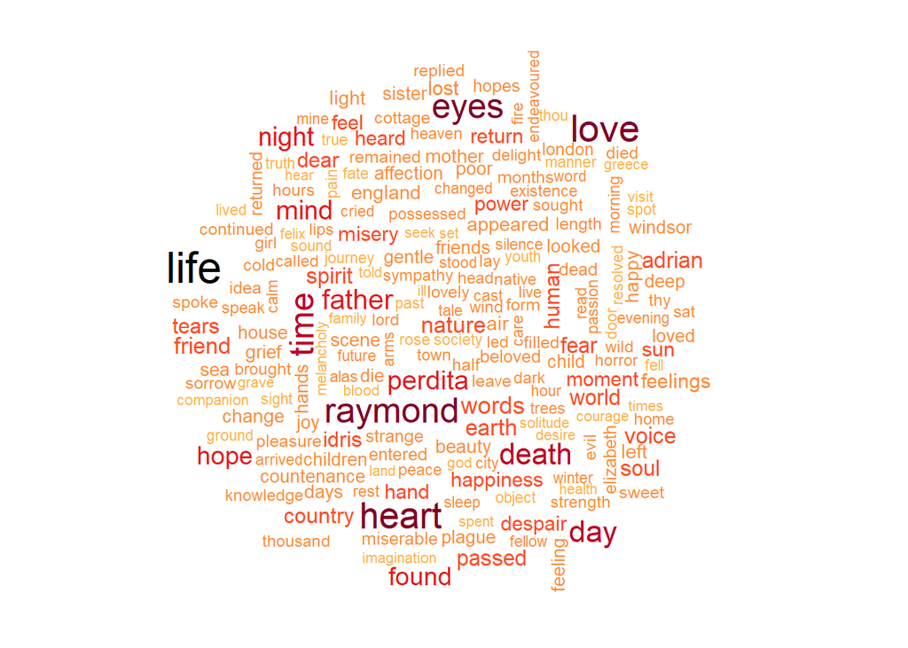

```r
spooky_wrd_MWS <- spooky_wrd %>%
  filter(author == "MWS") %>%
  group_by(word) %>%
  summarise(n = sum(n)) %>%
  ungroup()
wordcloud(spooky_wrd_MWS$word, spooky_wrd_MWS$n,
          max.words = 200, scale = c(2.0,0.5),
          colors = RColorBrewer::brewer.pal(9, "YlOrRd")[4:10])
```

It seems that Mary Shelley is more focused on the human body and relationships.

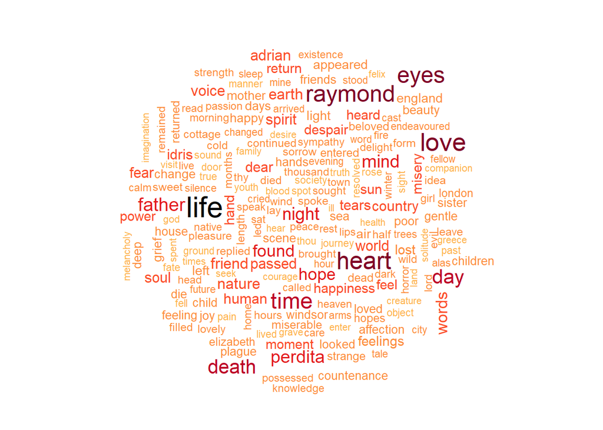

```r
spooky_wrd_EAP <- spooky_wrd %>%
  filter(author == "EAP") %>%
  group_by(word) %>%
  summarise(n = sum(n)) %>%
  ungroup()
wordcloud(spooky_wrd_MWS$word, spooky_wrd_MWS$n,
          max.words = 200, scale = c(2.0,0.5),
          colors = RColorBrewer::brewer.pal(9, "YlOrRd")[4:10])
```

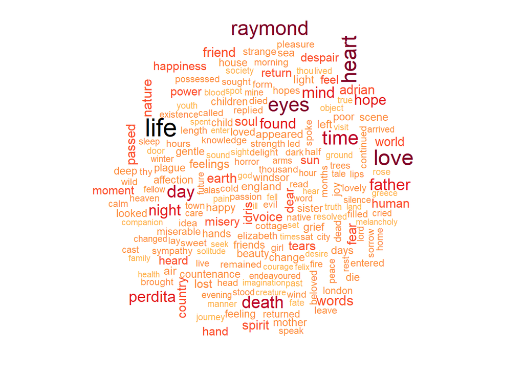

```r
spooky_wrd_HPL <- spooky_wrd %>%
  filter(author == "HPL") %>%
  group_by(word) %>%
  summarise(n = sum(n)) %>%
  ungroup()
wordcloud(spooky_wrd_MWS$word, spooky_wrd_MWS$n,
          max.words = 200, scale = c(2.0,0.5),
          colors = RColorBrewer::brewer.pal(9, "YlOrRd")[4:10])
```

# Similarity of authors

[figure not shown]

```r
simi_author <- spooky_wrd %>%
   spread(author, n, fill = 0) %>%
   na.omit()

simi_word <- spooky_wrd %>%
   spread(word, n, fill = 2) %>%
   na.omit()

corrgram(simi_author, lower.panel = panel.shade, upper.panel = panel.cor)
```

Take Edgar Allan Poe as consideration, comparing to HP Lovecraft and Mary Shelley. We witnessed that there are certain words like “found”, “hand” and etc. are in common.

It will also be interesting to see whether there is any major difference among the authors about the genders emphasis of the fictions.

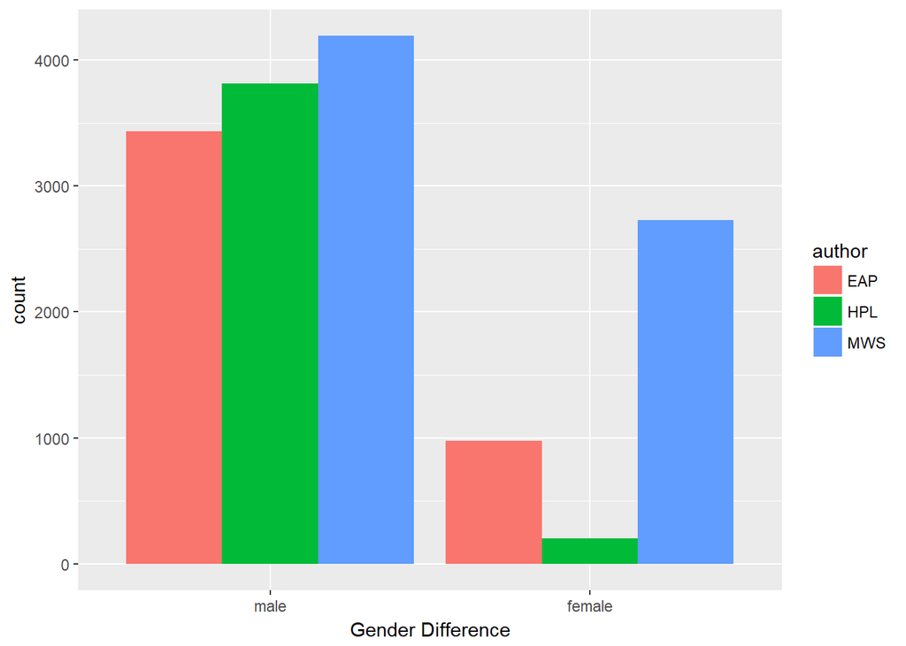

```r
p  <- spookydata %>%
  unnest_tokens(word, text) %>%

  mutate(female = ( word == "she" | word == "her" | word == "hers" | word == "female" | word == "girl"|
                    word == "woman" | word == "lady" | word == "madam" |
                    word == "women" )) %>%
  mutate(male = ( word == "he" | word == "him" | word == "his" | word == "male" |word == "boy"|
                    word == "man" | word == "gentleman" | word == "sir" |
                    word == "lord" | word == "men" )) %>%
  unite(sex, female, male) %>%
  mutate(sex = fct_recode(as.factor(sex), male = "FALSE_TRUE",
                          female = "TRUE_FALSE", other = "FALSE_FALSE")) %>%
  filter(sex != "other") %>%
  ggplot(aes(sex, fill = author)) +
  labs(x = "Gender Difference") +
  geom_bar(position = "dodge")

plot(p)
```

Apparently, male characters are the leading gender in the horror fictions. Separately, HP Lovecraft is much more focused on the male characters than the other authors. Then, what exactly words did they use as gender indications. Let’s find it out.

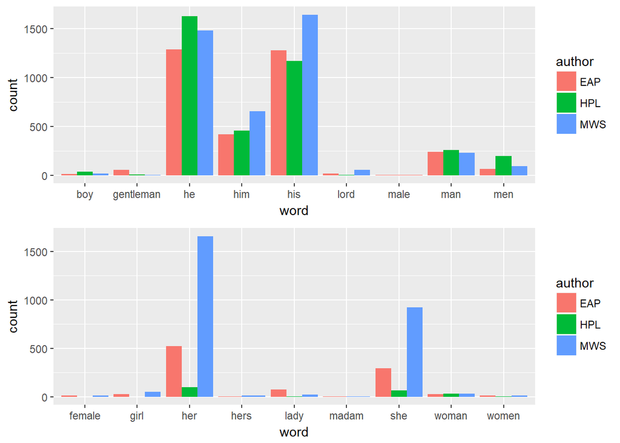

```r
p1 <- spookydata %>%
  unnest_tokens(word, text) %>%
  filter((word == "him") | (word == "his") | (word == "man") | (word == "gentleman") | (word == "male") | (word == "lord") |(word == "boy")| (word == "he") | (word == "men")) %>%
  ggplot(aes(word, fill = author)) +
  geom_bar(position = "dodge")

p2 <- spookydata %>%
  unnest_tokens(word, text) %>%
  filter(( word == "she" | word == "her" | word == "hers" | word == "female" | word == "girl"|
                    word == "woman" | word == "lady" | word == "madam" |
                    word == "women" )) %>%
  ggplot(aes(word, fill = author)) +
  geom_bar(position = "dodge")

layout <- matrix(c(1,2),2,1,byrow=TRUE)
multiplot(p1, p2, layout=layout)
```

Apparently, the simple words“he, him, his” and “her”,“she” are the most common words in the charts. And it is of no apparent difference among the authors about the preference of the words in each gender.

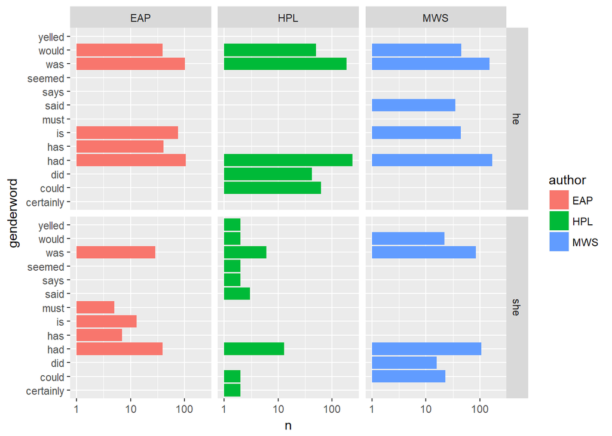

```r
t_heshe <- spookydata %>%
  unnest_tokens(bigram, text, token = "ngrams", n = 2) %>%
  separate(bigram, c("word1", "genderword"), sep = " ")

t_heshe %>%
  filter(word1 == "she" | word1 == "he" ) %>%
  group_by(author, word1, genderword) %>%
  count() %>%
  ungroup() %>%
  group_by(author, word1) %>%
  top_n(5,n) %>%
  ggplot(aes(genderword, n, fill = author)) +
  geom_col() +
  scale_y_log10() +
  coord_flip() +
  facet_grid(word1 ~ author)
```

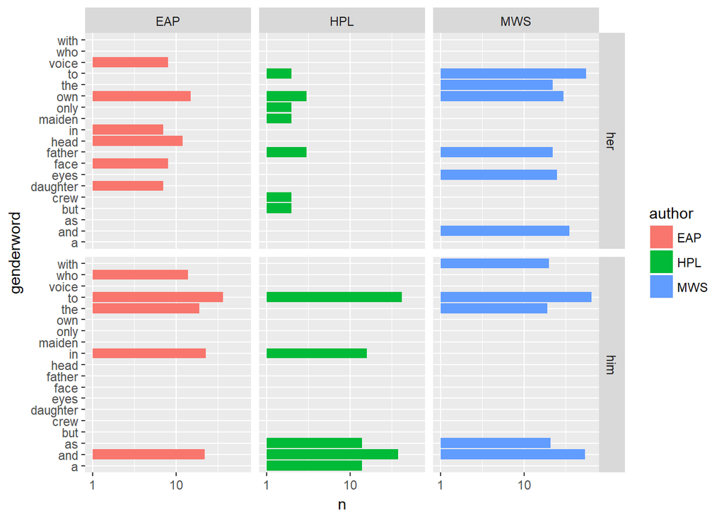

```r
t_himh <- spookydata %>%
  unnest_tokens(bigram, text, token = "ngrams", n = 2) %>%
  separate(bigram, c("word1", "genderword"), sep = " ")

t_himh %>%
  filter(word1 == "her" | word1 == "him" ) %>%
  group_by(author, word1, genderword) %>%
  count() %>%
  ungroup() %>%
  group_by(author, word1) %>%
  top_n(5,n) %>%
  ggplot(aes(genderword, n, fill = author)) +
  geom_col() +
  scale_y_log10() +
  coord_flip() +
  facet_grid(word1 ~ author)
```

# Sentiment Analysis Part

## Most frequent words

For the speeches, we remove extra white space, convert all letters to the lower case, remove stop words, removed empty words due to formatting errors, and remove punctuation.

After cleaning up corpus, we compute TDM. Documemnt Term Matrix (DTM) or Term Document Matrix (TDM) is a document that lists all occurrences of words of each document.

```r
corpus_eap <-  Corpus(VectorSource(spooky_wrd_EAP$word))
corpus_eap<-tm_map(corpus_eap, content_transformer(tolower))
corpus_eap<-tm_map(corpus_eap, removeWords, stopwords("english"))
corpus_eap<-tm_map(corpus_eap, removeWords, character(0))
corpus_eap<-tm_map(corpus_eap, removePunctuation)
tdm.all_eap<-TermDocumentMatrix(corpus_eap)
tdm.tidy_eap=tidy(tdm.all_eap)
tdm.overall_eap=summarise(group_by(tdm.tidy_eap, term), sum(count))

corpus_hpl <-  Corpus(VectorSource(spooky_wrd_HPL$word))
corpus_hpl<-tm_map(corpus_hpl, content_transformer(tolower))
corpus_hpl<-tm_map(corpus_hpl, removeWords, stopwords("english"))
corpus_hpl<-tm_map(corpus_hpl, removeWords, character(0))
corpus_hpl<-tm_map(corpus_hpl, removePunctuation)
tdm.all_hpl<-TermDocumentMatrix(corpus_hpl)
tdm.tidy_hpl=tidy(tdm.all_hpl)
tdm.overall_hpl=summarise(group_by(tdm.tidy_hpl, term), sum(count))

corpus_mws <-  Corpus(VectorSource(spooky_wrd_MWS$word))
corpus_mws<-tm_map(corpus_mws, content_transformer(tolower))
corpus_mws<-tm_map(corpus_mws, removeWords, stopwords("english"))
corpus_mws<-tm_map(corpus_mws, removeWords, character(0))
corpus_mws<-tm_map(corpus_mws, removePunctuation)
tdm.all_mws<-TermDocumentMatrix(corpus_mws)
tdm.tidy_mws=tidy(tdm.all_mws)
tdm.overall_mws=summarise(group_by(tdm.tidy_mws, term), sum(count))
```

## Emotion

```r
spooky_wrd <- spookydata %>% unnest_tokens(word, text)%>%
  anti_join(stop_words, by = "word")
```

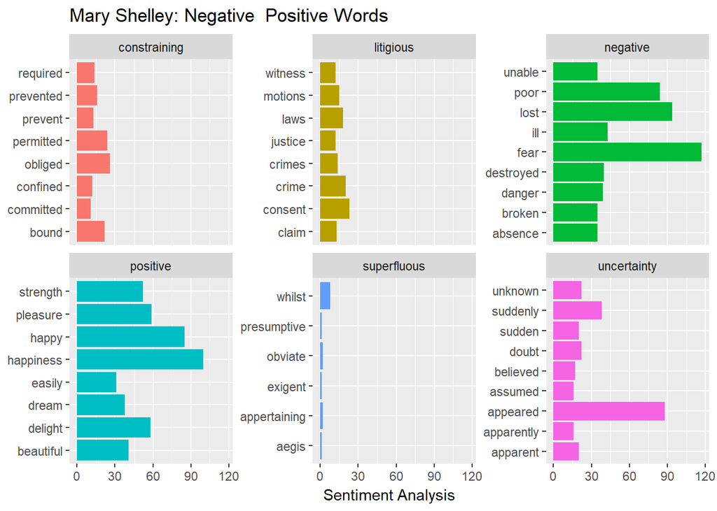

```r
spooky_wrd %>%
    filter(author == "MWS") %>%
  inner_join(get_sentiments("loughran"), by = "word") %>%
  count(word, sentiment, sort = TRUE) %>%
  ungroup() %>%
  group_by(sentiment) %>%
  top_n(8, n) %>%
  mutate(word = reorder(word, n)) %>%
  ungroup() %>%
  ggplot(aes(word, n, fill = sentiment)) +
  geom_col(show.legend = FALSE) +
  facet_wrap(~sentiment, scales = "free_y") +
  coord_flip()+
  labs( x = NULL,y = "Sentiment Analysis") +
  ggtitle("Mary Shelley: Negative  Positive Words")
```

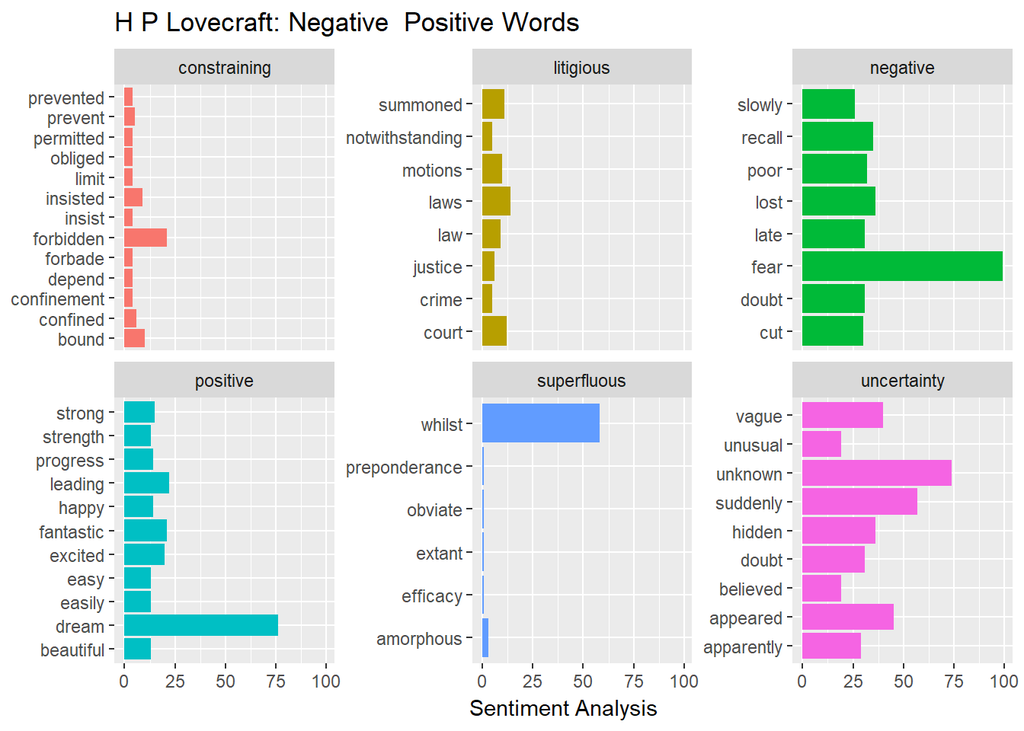

```r
spooky_wrd %>%
    filter(author == "HPL") %>%
  inner_join(get_sentiments("loughran"), by = "word") %>%
  count(word, sentiment, sort = TRUE) %>%
  ungroup() %>%
  group_by(sentiment) %>%
  top_n(8, n) %>%
  mutate(word = reorder(word, n)) %>%
  ungroup() %>%
  ggplot(aes(word, n, fill = sentiment)) +
  geom_col(show.legend = FALSE) +
  facet_wrap(~sentiment, scales = "free_y") +
  coord_flip()+
  labs( x = NULL,y = "Sentiment Analysis") +
  ggtitle("H P Lovecraft: Negative  Positive Words")
```

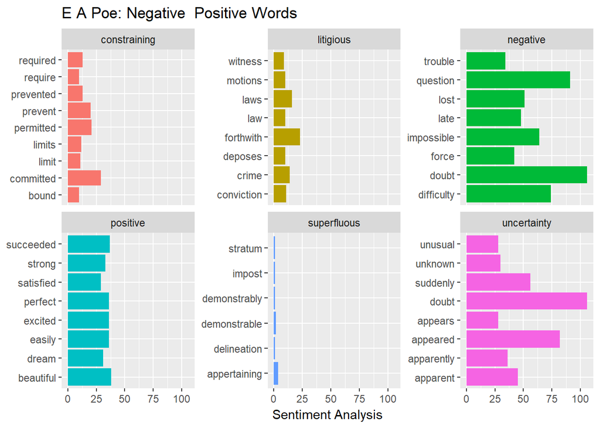

```r
spooky_wrd %>%
    filter(author == "EAP") %>%
  inner_join(get_sentiments("loughran"), by = "word") %>%
  count(word, sentiment, sort = TRUE) %>%
  ungroup() %>%
  group_by(sentiment) %>%
  top_n(8, n) %>%
  mutate(word = reorder(word, n)) %>%
  ungroup() %>%
  ggplot(aes(word, n, fill = sentiment)) +
  geom_col(show.legend = FALSE) +
  facet_wrap(~sentiment, scales = "free_y") +
  coord_flip()+
  labs( x = NULL,y = "Sentiment Analysis") +
  ggtitle("E A Poe: Negative  Positive Words")
```

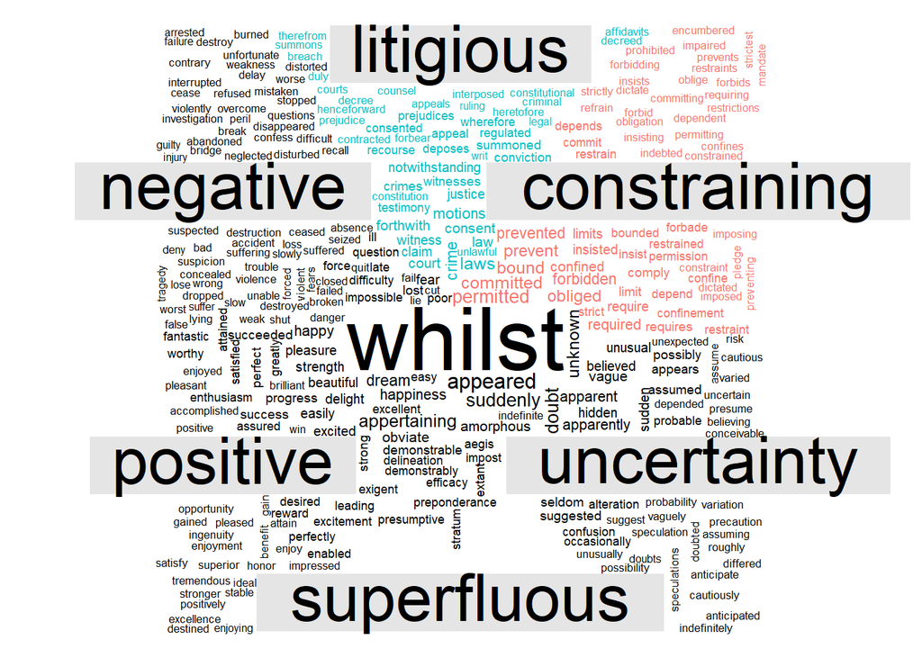

```r
spooky_wrd %>%
  inner_join(get_sentiments("loughran"), by = "word") %>%
  count(word, sentiment, sort = TRUE) %>%
  acast(word ~ sentiment, value.var = "n", fill = 0) %>%
  comparison.cloud(colors = c("#F8766D", "#00BFC4"), max.words = 500)
```

#The super negative Index

Define the super negative Index = (#uncertainty+#Negative + #constraining)/(#Postive + #Negative + #constraining + #uncertainty)

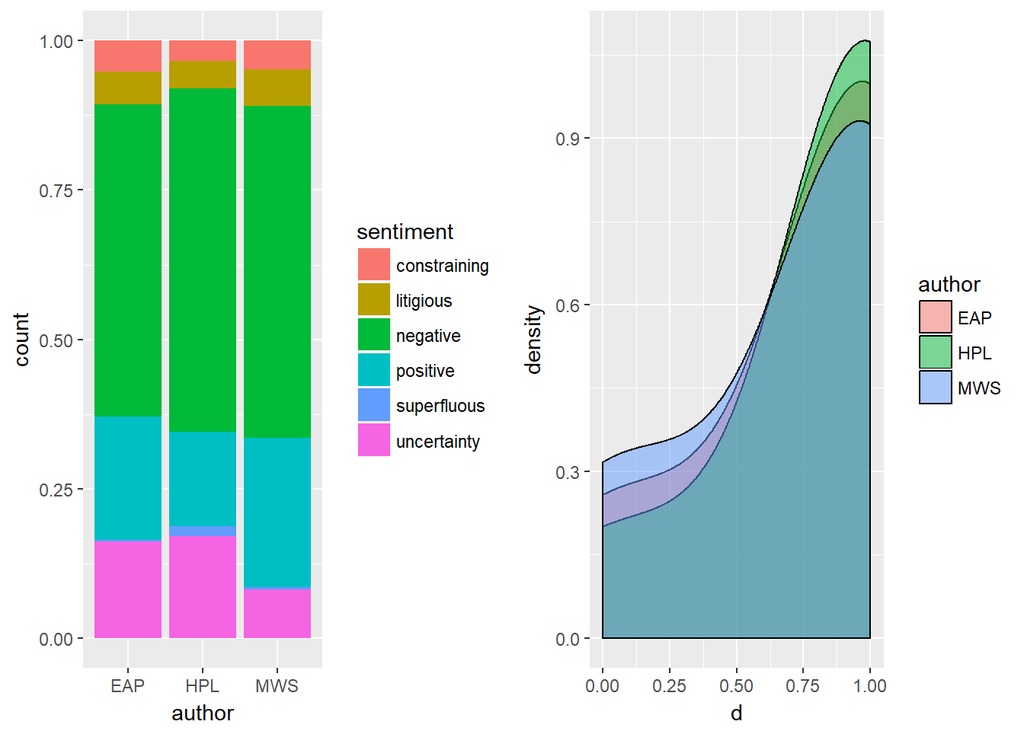

```r
pic1 <- spooky_wrd %>%
  inner_join(get_sentiments("loughran"), by = "word") %>%
  ggplot(aes(author, fill = sentiment)) +
  geom_bar(position = "fill")

pic2 <- spooky_wrd %>%
  inner_join(get_sentiments("loughran"), by = "word") %>%
  group_by(author, id, sentiment) %>%
  count() %>%
  spread(sentiment, n, fill = 0) %>%
  group_by(author, id) %>%
  summarise(neg = sum(negative),
            con = sum(constraining),
            unc = sum(uncertainty),
            pos = sum(positive)) %>%
  arrange(id) %>%
  mutate(frac_neg = 1 - pos/(pos + neg + con+unc)) %>%
  ggplot(aes(frac_neg, fill = author)) +
  geom_density(bw = .3, alpha = 0.5) +
  theme(legend.position = "right") +
  labs(x = "d")

layout <- matrix(c(1,2),1,2,byrow=TRUE)
multiplot(pic1, pic2, layout=layout)
```

#Topic Models First, let’s explore the structure using Latent Dirichlet Allocation Moddel(LDA). This method yields an unsupervised classifictaion of documents. By seeking the clusters corresponding to different topics, we will be able to find underlting structure in the data.

To analyze it, we need first transform the data into the document term matrices(DTM).

```r
spooky_wrd<-spookydata %>% unnest_tokens(word, text)

freq <- spooky_wrd %>%
  anti_join(stop_words, by = "word") %>%
        count(id, word)
spooky_tm <- cast_dtm(freq, id, word, n)
spooky_tm
```

```
## <<DocumentTermMatrix (documents: 19467, terms: 24949)>>
## Non-/sparse entries: 194186/485487997
## Sparsity           : 100%
## Maximal term length: 19
## Weighting          : term frequency (tf)
```

Now, let’s perform LDA for 10 topics. We may assume that each of our authors contribute to more than one story to our text.

```r
spooky_lda <- LDA(spooky_tm, k = 10, method = "Gibbs", control = list(seed = 1234))
```

After training, let’s visualize the final effects of the data.

```r
spooky_lda.topics <- as.matrix(topics(spooky_lda))
table(c(1:10, spooky_lda.topics))
```

```
##
##    1    2    3    4    5    6    7    8    9   10
## 2999 2556 2241 1981 1792 1892 1783 1573 1489 1171
```

```r
write.csv(spooky_lda.topics, file = paste("../out/LDA_Gibbs",10,"Doc_Topics.csv"))
spooky_topic <- spooky_lda.topics
```

As the chart show, beta indicates the probability that this particular word belongs to that topic.

```r
spooky_lda.terms <- as.matrix(terms(spooky_lda,5))
spooky_lda.terms
```

```
##      Topic 1  Topic 2  Topic 3   Topic 4    Topic 5  Topic 6   Topic 7
## [1,] "time"   "house"  "night"   "found"    "left"   "day"     "eyes"
## [2,] "body"   "door"   "heard"   "time"     "head"   "raymond" "heart"
## [3,] "object" "half"   "strange" "days"     "hand"   "friend"  "love"
## [4,] "idea"   "found"  "fear"    "called"   "length" "father"  "words"
## [5,] "air"    "street" "dead"    "appeared" "feet"   "passed"  "death"
##      Topic 8 Topic 9     Topic 10
## [1,] "light" "matter"    "life"
## [2,] "sea"   "doubt"     "mind"
## [3,] "dark"  "speak"     "nature"
## [4,] "city"  "attention" "world"
## [5,] "black" "word"      "human"
```

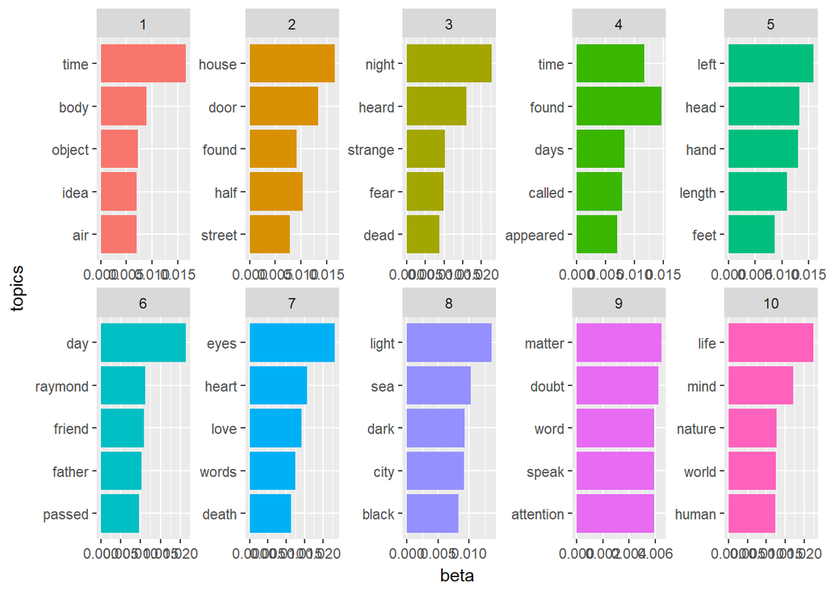

```r
chapter_topics <- tidy(spooky_lda, matrix = "beta")

 chapter_topics%>%
  group_by(topic) %>%
  top_n(5, beta) %>%
  ungroup() %>%
  arrange(topic, -beta) %>%
  mutate(topics = reorder(term, beta)) %>%
  ggplot(aes(topics, beta, fill = factor(topic))) +
  geom_col(show.legend = FALSE) +
  facet_wrap(~ topic, scales = "free", ncol = 5) +
  coord_flip()
```

We may wonder how are the topics assocaited with each author?

```r
eap <- spooky_wrd %>%
   filter(author == 'EAP')
hpl <- spooky_wrd %>%
   filter(author == 'HPL')
mws <- spooky_wrd %>%
   filter(author == 'MWS')
```

```r
freq <- eap %>%
    anti_join(stop_words, by = "word") %>%
        count(id, word)
spooky_tm_EAP <- cast_dtm(freq, id, word, n)

freq <- hpl %>%
    anti_join(stop_words, by = "word") %>%
        count(id, word)
spooky_tm_HPL <- cast_dtm(freq, id, word, n)

freq <- mws %>%
    anti_join(stop_words, by = "word") %>%
        count(id, word)
spooky_tm_MWS <- cast_dtm(freq, id, word, n)
```

```r
spooky_lda_EAP <- LDA(spooky_tm_EAP, method = "Gibbs", k = 10, control = list(seed = 1234))
spooky_lda_HPL <- LDA(spooky_tm_HPL, method = "Gibbs", k = 10, control = list(seed = 1234))
spooky_lda_MWS <- LDA(spooky_tm_MWS, method = "Gibbs", k = 10, control = list(seed = 1234))
```

```r
spooky_lda_EAP.topics <- as.matrix(topics(spooky_lda_EAP))
spooky_lda_EAP.terms <- as.matrix(terms(spooky_lda_EAP,5))
spooky_lda_HPL.topics <- as.matrix(topics(spooky_lda_HPL))
spooky_lda_HPL.terms <- as.matrix(terms(spooky_lda_HPL,5))
spooky_lda_MWS.topics <- as.matrix(topics(spooky_lda_MWS))
spooky_lda_MWS.terms <- as.matrix(terms(spooky_lda_MWS,5))
```

```r
spooky_topic_EAP <- tidy(spooky_lda_EAP, matrix = "beta")
spooky_topic_EAP %>% sample_n(5)
```

| topic | term | beta |
| --- | --- | --- |
| 7 | wife | 1.140264e-05 |
| 6 | consisting | 1.132644e-05 |
| 5 | falsities | 1.143916e-05 |
| 4 | tomahawk | 1.157957e-05 |
| 9 | propounding | 1.108168e-05 |

```r
spooky_topic_HPL <- tidy(spooky_lda_HPL, matrix = "beta")
spooky_topic_HPL %>% sample_n(5)
```

| topic | term | beta |
| --- | --- | --- |
| 9 | forthwith | 1.344845e-05 |
| 1 | fancied | 1.455257e-04 |
| 6 | neapolis | 1.323311e-05 |
| 5 | blandness | 1.302796e-05 |
| 7 | suffered | 2.718869e-04 |

```r
spooky_topic_MWS <- tidy(spooky_lda_MWS, matrix = "beta")
spooky_topic_MWS %>% sample_n(5)
```

| topic | term | beta |
| --- | --- | --- |
| 9 | enthroned | 1.542669e-04 |
| 9 | desiring | 1.402426e-05 |
| 7 | double | 1.329522e-05 |
| 9 | cadence | 1.402426e-05 |
| 5 | unendurable | 1.332001e-05 |

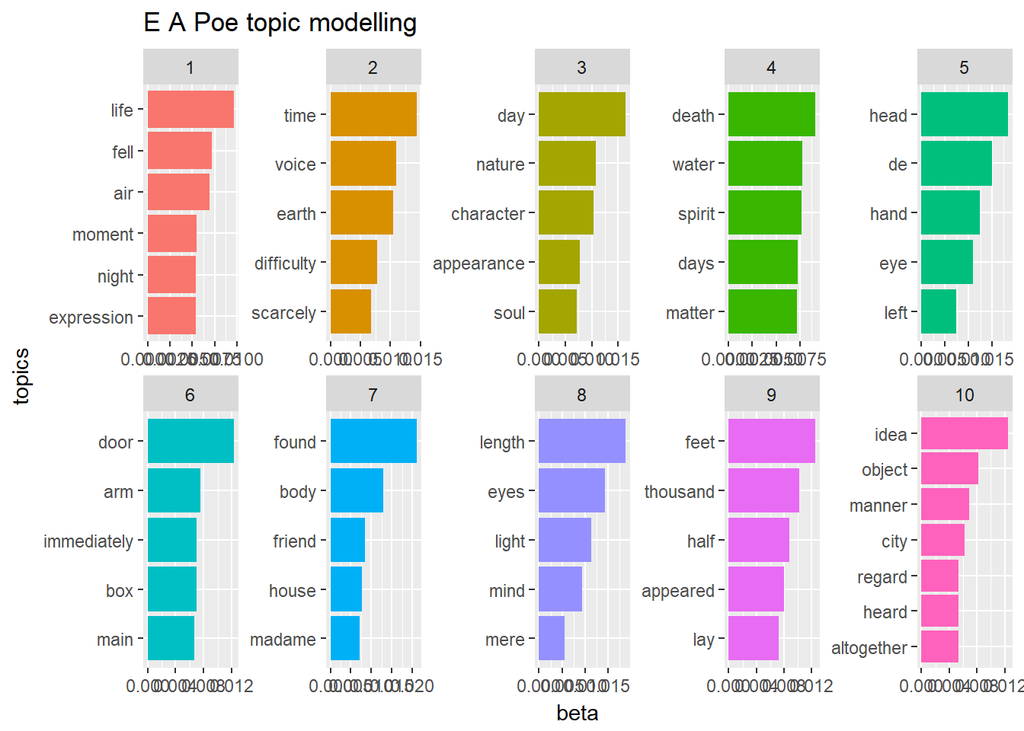

```r
spooky_topic_EAP %>%
  group_by(topic) %>%
  top_n(5, beta) %>%
  ungroup() %>%
  arrange(topic, -beta) %>%
  mutate(topics = reorder(term, beta)) %>%
  ggplot(aes(topics, beta, fill = factor(topic))) +
  geom_col(show.legend = FALSE) +
  facet_wrap(~ topic, scales = "free", ncol = 5) +
  coord_flip()+ggtitle("E A Poe topic modelling")
```

It is not hard to see that E.A.Poe’s ten topics distribution.Within topic1, he likes to quote the words:life, fell, air, moment, night and expression.

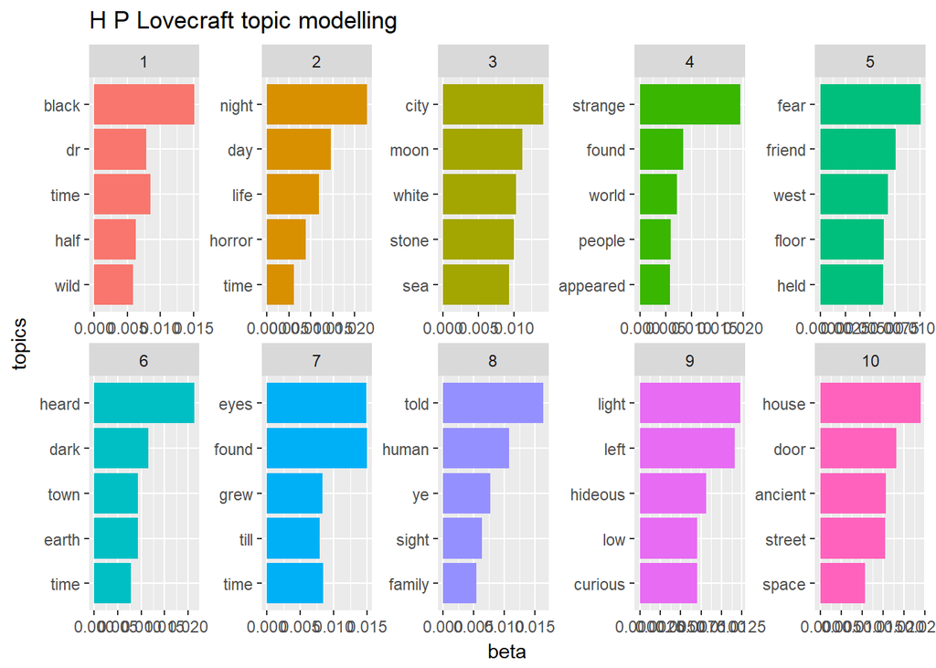

```r
spooky_topic_HPL %>%
  group_by(topic) %>%
  top_n(5, beta) %>%
  ungroup() %>%
  arrange(topic, -beta) %>%
  mutate(topics = reorder(term, beta)) %>%
  ggplot(aes(topics, beta, fill = factor(topic))) +
  geom_col(show.legend = FALSE) +
  facet_wrap(~ topic, scales = "free", ncol = 5) +
  coord_flip()+ggtitle("H P Lovecraft topic modelling")
```

Different from E.A.Poe, H.P.Lovecraft’s focus on topic 1 lies on the words:black, dr, time, half and wild.

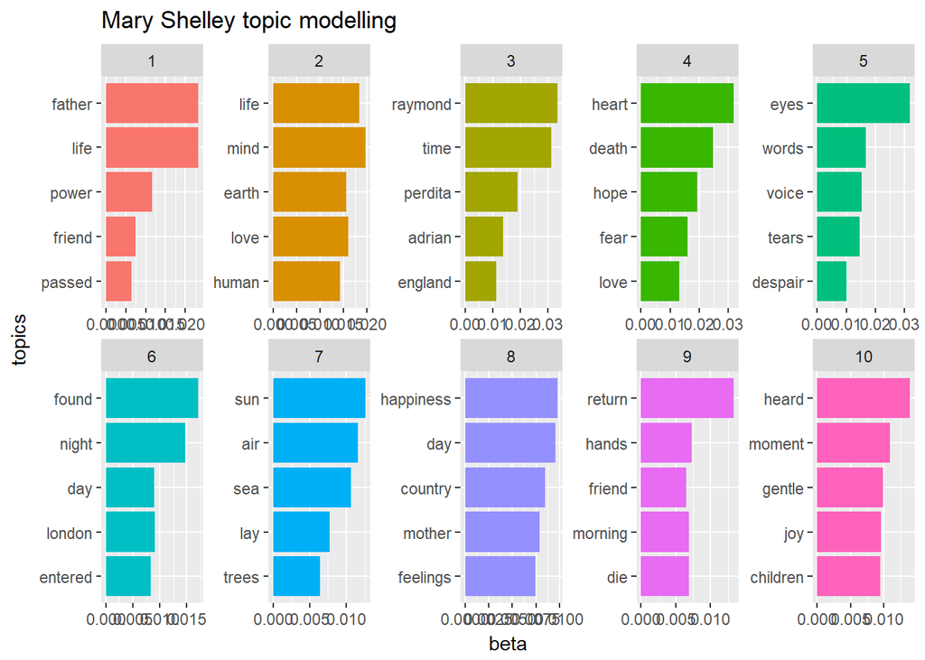

```r
spooky_topic_MWS %>%
  group_by(topic) %>%
  top_n(5, beta) %>%
  ungroup() %>%
  arrange(topic, -beta) %>%
  mutate(topics = reorder(term, beta)) %>%
  ggplot(aes(topics, beta, fill = factor(topic))) +
  geom_col(show.legend = FALSE) +
  facet_wrap(~ topic, scales = "free", ncol = 5) +
  coord_flip()+ggtitle("Mary Shelley topic modelling")
```